# Code Brews 🍻

###### Contributors:

###### Nathon Burwick, Rod Hughes, Victoria Sanders, Jason Hanlin,

###### Kelly Hendre, Jarvis Moy, Lynn Orr, Wen Chiou, Talita Urzenda

## Project Description

We are a brewery, Code Brews, looking to expand to a new location. Our goal is to determine potentially successful business locations based on

- Selling price of imported and domestic beer
- Monthly expenses
- Number of customers
- Transportation costs
- Production costs
- Location

## Data Collection & Cleaning (ETL)

When identifying the data we needed to collect, we wanted to identify a few potential key indicators about our target market and potential locations for analysis. This led us to searching for data from the following sources:

- Cost of Living Data - Kaggle - https://www.kaggle.com/datasets/mvieira101/global-cost-of-living?select=cost-of-living.csv
- Craft Beer Data - Kaggle - https://www.kaggle.com/nickhould/craft-cans
- US Census Bureau - API
- Open Brewery DB - API

We chose the cost of living data set from Kaggle because the source provided a good approximation of the average cost of goods and services for approximately 5,000 cities globally.

We then went to the US Census Bureau to collect various data sets via their API to gain demographic and economic insights on potential target markets within the US.

Finally, we used the Open Brewery DB API to find open breweries already existing or in planning phases which could be potential competitors.

We extracted and cleaned all this data through the following process.

```python
# Read Resource csv files into script
df_1 = pd.read_csv(os.path.join('..','Resources', 'cost-of-living.csv'), delimiter=',', index_col=0, )
df_2 = pd.read_csv(os.path.join('..','Resources', 'cost-of-living_v2.csv'), delimiter=',' )
# Display Data Frames
print('Cost Of Living (V1):')
display(df_1.head())
print('Cost Of Living (V2):')
display(df_2.head())
```

```
Cost Of Living (V1):
```

|  | city | country | x1 | x2 | x3 | x4 | x5 | x6 | x7 | x8 | ... | x47 | x48 | x49 | x50 | x51 | x52 | x53 | x54 | x55 | data_quality |
| --- | --- | --- | --- | --- | --- | --- | --- | --- | --- | --- | --- | --- | --- | --- | --- | --- | --- | --- | --- | --- | --- |
| 0 | Delhi | India | 4.90 | 22.04 | 4.28 | 1.84 | 3.67 | 1.78 | 0.48 | 0.19 | ... | 36.26 | 223.87 | 133.38 | 596.16 | 325.82 | 2619.46 | 1068.90 | 586.35 | 7.96 | 1 |
| 1 | Shanghai | China | 5.59 | 40.51 | 5.59 | 1.12 | 4.19 | 3.96 | 0.52 | 0.32 | ... | 121.19 | 1080.07 | 564.30 | 2972.57 | 1532.23 | 17333.09 | 9174.88 | 1382.83 | 5.01 | 1 |
| 2 | Jakarta | Indonesia | 2.54 | 22.25 | 3.50 | 2.02 | 3.18 | 2.19 | 0.59 | 0.27 | ... | 80.32 | 482.85 | 270.15 | 1117.69 | 584.37 | 2694.05 | 1269.44 | 483.19 | 9.15 | 1 |
| 3 | Manila | Philippines | 3.54 | 27.40 | 3.54 | 1.24 | 1.90 | 2.91 | 0.93 | 0.51 | ... | 61.82 | 559.52 | 281.78 | 1754.40 | 684.81 | 3536.04 | 2596.44 | 419.02 | 7.80 | 1 |
| 4 | Seoul | South Korea | 7.16 | 52.77 | 6.03 | 3.02 | 4.52 | 3.86 | 1.46 | 0.78 | ... | 108.30 | 809.83 | 583.60 | 2621.05 | 1683.74 | 21847.94 | 10832.90 | 2672.23 | 3.47 | 1 |

5 rows × 58 columns

```
Cost Of Living (V2):
```

|  | city | country | x1 | x2 | x3 | x4 | x5 | x6 | x7 | x8 | ... | x47 | x48 | x49 | x50 | x51 | x52 | x53 | x54 | x55 | data_quality |
| --- | --- | --- | --- | --- | --- | --- | --- | --- | --- | --- | --- | --- | --- | --- | --- | --- | --- | --- | --- | --- | --- |
| 0 | Seoul | South Korea | 7.68 | 53.78 | 6.15 | 3.07 | 4.99 | 3.93 | 1.48 | 0.79 | ... | 110.36 | 742.54 | 557.52 | 2669.12 | 1731.08 | 22067.70 | 10971.90 | 2689.62 | 3.47 | 1 |
| 1 | Shanghai | China | 5.69 | 39.86 | 5.69 | 1.14 | 4.27 | 3.98 | 0.53 | 0.33 | ... | 123.51 | 1091.93 | 569.88 | 2952.70 | 1561.59 | 17746.11 | 9416.35 | 1419.87 | 5.03 | 1 |
| 2 | Guangzhou | China | 4.13 | 28.47 | 4.98 | 0.85 | 1.71 | 3.54 | 0.44 | 0.33 | ... | 43.89 | 533.28 | 317.45 | 1242.24 | 688.05 | 12892.82 | 5427.45 | 1211.68 | 5.19 | 1 |
| 3 | Mumbai | India | 3.68 | 18.42 | 3.68 | 2.46 | 4.30 | 2.48 | 0.48 | 0.19 | ... | 41.17 | 522.40 | 294.05 | 1411.12 | 699.80 | 6092.45 | 2777.51 | 640.81 | 7.96 | 1 |
| 4 | Delhi | India | 4.91 | 22.11 | 4.30 | 1.84 | 3.68 | 1.77 | 0.49 | 0.19 | ... | 36.50 | 229.84 | 135.31 | 601.02 | 329.15 | 2506.73 | 1036.74 | 586.46 | 8.06 | 1 |

5 rows × 58 columns

Here we wanted to merge and take an average of the year over year data we found from the Kaggle source to help with our estimates and cleaning of data. We rename the columns to a more descriptive name to better identify what the data is telling us.

```python
# Filter to United States
US_df = df_merged[df_merged['Country'] == 'United States']

# Identify Any Duplicate Cities
dup_cities = US_df[US_df['City'].duplicated()]['City']
print(f"There were {len(dup_cities)} duplicates")

# Explore Duplicate Data
dup_df = US_df[US_df['City'].isin(dup_cities)]
#Display Duplicate Data
display(dup_df.sort_values('City').head())
print(dup_df.shape)
```

```
There were 459 duplicates
```

|  | City | Country | Avg Meal Inexp. Restaurant | Avg Meal (For 2) Mid-Range Restaurant | McMeal at McDonalds | Domestic Beer (Restaurant) | Imported Beer (Restaurant) | Cappuccino | Coke/Pepsi (Restaurant) | Water (Restaurant) | ... | 1bd Apt. (City Center) | 1bd Apt. (Outside Center) | 3bd Apt. (City Center) | 3bd Apt. (Outside Center) | Price/sqm Buy Apt. (City Center) | Price/sqm Buy Apt. (Outside Center) | Avg. Monthly Income (After Tax) | Avg. Mortgage Interest (%) | Data Quality | Merge |
| --- | --- | --- | --- | --- | --- | --- | --- | --- | --- | --- | --- | --- | --- | --- | --- | --- | --- | --- | --- | --- | --- |
| 6936 | Abilene | United States | 13.5 | 60.0 | 7.5 | 3.50 | 6.00 | 4.33 | 3.83 | 2.12 | ... | 600.0 | 800.0 | 1500.0 | 1500.0 | NaN | NaN | 4015.89 | 5.12 | 0 | right_only |
| 2266 | Abilene | United States | 13.5 | 60.0 | 7.0 | 3.50 | 6.00 | 4.33 | 3.83 | 2.12 | ... | 600.0 | 800.0 | 1500.0 | 1500.0 | NaN | NaN | 3423.61 | 5.12 | 0 | left_only |
| 8410 | Adrian | United States | 17.5 | 45.0 | 7.0 | 3.75 | 3.62 | 3.86 | 2.25 | 1.35 | ... | 750.0 | 600.0 | 1400.0 | 1000.0 | NaN | NaN | NaN | 3.00 | 0 | right_only |
| 4038 | Adrian | United States | 17.5 | 45.0 | 7.0 | 3.75 | 3.62 | 3.86 | 2.25 | 1.35 | ... | 750.0 | 600.0 | 1400.0 | 1000.0 | NaN | NaN | NaN | 3.00 | 0 | left_only |
| 8910 | Airway Heights | United States | 15.0 | 77.5 | 10.0 | 5.00 | 7.00 | 5.17 | 2.86 | 2.00 | ... | 1300.0 | 1300.0 | 1800.0 | 1800.0 | 6070.85 | 4886.82 | NaN | 5.43 | 0 | right_only |

5 rows × 59 columns

```
(918, 59)
```

```python
# Because the data seems to be a difference only between the original data sets
# we will take an average of the two duplicates
US_df_grouped = US_df.groupby('City').mean(numeric_only=True)

#Display Cleaned Data
display(US_df_grouped.head())
print(US_df_grouped.shape)
```

| City | Avg Meal Inexp. Restaurant | Avg Meal (For 2) Mid-Range Restaurant | McMeal at McDonalds | Domestic Beer (Restaurant) | Imported Beer (Restaurant) | Cappuccino | Coke/Pepsi (Restaurant) | Water (Restaurant) | Milk | Bread (Loaf) | ... | Leather Business Shoes | 1bd Apt. (City Center) | 1bd Apt. (Outside Center) | 3bd Apt. (City Center) | 3bd Apt. (Outside Center) | Price/sqm Buy Apt. (City Center) | Price/sqm Buy Apt. (Outside Center) | Avg. Monthly Income (After Tax) | Avg. Mortgage Interest (%) | Data Quality |
| --- | --- | --- | --- | --- | --- | --- | --- | --- | --- | --- | --- | --- | --- | --- | --- | --- | --- | --- | --- | --- | --- |
| Abilene | 13.5 | 60.0 | 7.25 | 3.50 | 6.00 | 4.33 | 3.83 | 2.12 | 0.88 | 3.59 | ... | 123.330 | 600.0 | 800.0 | 1500.00 | 1500.0 | NaN | NaN | 3719.75 | 5.12 | 0.0 |
| Acton | NaN | 102.5 | 10.00 | 8.00 | 7.00 | 6.67 | 4.00 | 2.75 | 1.32 | 4.84 | ... | 106.670 | 1600.0 | 1400.0 | 2800.00 | 2500.0 | 3767.37 | 2260.42 | 4500.00 | 4.00 | 0.0 |
| Acworth | 16.0 | 45.0 | 7.50 | 5.00 | 5.50 | 5.92 | 1.67 | 2.25 | 0.69 | 2.89 | ... | 55.000 | 950.0 | 800.0 | 1733.33 | 1225.0 | 1367.02 | NaN | 4166.67 | NaN | 0.0 |
| Adrian | 17.5 | 45.0 | 7.00 | 3.75 | 3.62 | 3.86 | 2.25 | 1.35 | 0.66 | 2.36 | ... | 59.165 | 750.0 | 600.0 | 1400.00 | 1000.0 | NaN | NaN | NaN | 3.00 | 0.0 |
| Agoura Hills | NaN | NaN | NaN | NaN | NaN | 4.50 | NaN | 1.00 | NaN | NaN | ... | 120.000 | 1900.0 | 1800.0 | 3500.00 | 3000.0 | 4144.11 | NaN | NaN | 2.62 | 0.0 |

5 rows × 56 columns

```
(1076, 56)
```

We also were interested in identifying potential beers which would be popular in our new market. Therefore we pulled in the Craft Beers Data frame to gain insights to a few popular brews in the cities available to us. We eliminated other cities not contained in the data from there for managability.

```python
# Read csv files from Resources - https://www.kaggle.com/nickhould/craft-cans
beer_df = pd.read_csv(os.path.join('..', 'Resources', 'beers.csv'), delimiter=',', index_col=0, header=0,
                      names=['ABV (%)', 'IBU', 'Beer ID', 'Beer Name', 'Beer Style', 'Brewery ID', 'Ounces'])
brewery_df = pd.read_csv(os.path.join('..', 'Resources', 'breweries.csv'), delimiter=',', header=0,
                         names=['Brewery ID','Brewery Name', 'City', 'State'])

# Display Preview of Data
display(beer_df.head())
display(brewery_df.head())
```

|  | ABV (%) | IBU | Beer ID | Beer Name | Beer Style | Brewery ID | Ounces |
| --- | --- | --- | --- | --- | --- | --- | --- |
| 0 | 0.050 | NaN | 1436 | Pub Beer | American Pale Lager | 408 | 12.0 |
| 1 | 0.066 | NaN | 2265 | Devil's Cup | American Pale Ale (APA) | 177 | 12.0 |
| 2 | 0.071 | NaN | 2264 | Rise of the Phoenix | American IPA | 177 | 12.0 |
| 3 | 0.090 | NaN | 2263 | Sinister | American Double / Imperial IPA | 177 | 12.0 |
| 4 | 0.075 | NaN | 2262 | Sex and Candy | American IPA | 177 | 12.0 |

|  | Brewery ID | Brewery Name | City | State |
| --- | --- | --- | --- | --- |
| 0 | 0 | NorthGate Brewing | Minneapolis | MN |
| 1 | 1 | Against the Grain Brewery | Louisville | KY |
| 2 | 2 | Jack's Abby Craft Lagers | Framingham | MA |
| 3 | 3 | Mike Hess Brewing Company | San Diego | CA |
| 4 | 4 | Fort Point Beer Company | San Francisco | CA |

```python
# Drop Bitterness Measurement column for too many nulls and drop beers of unknown alcoholic content
df_merged.dropna(subset='ABV (%)', inplace=True)
df_merged = df_merged[['ABV (%)', 'Beer ID', 'Beer Name', 'Beer Style',
                       'Brewery ID', 'Ounces', 'Brewery Name','City', 'State']]
df_merged['ABV (%)'] = df_merged['ABV (%)'] * 100
# Display DF
display(df_merged.head())
```

|  | ABV (%) | Beer ID | Beer Name | Beer Style | Brewery ID | Ounces | Brewery Name | City | State |
| --- | --- | --- | --- | --- | --- | --- | --- | --- | --- |
| 0 | 5.0 | 1436 | Pub Beer | American Pale Lager | 408 | 12.0 | 10 Barrel Brewing Company | Bend | OR |
| 1 | 6.6 | 2265 | Devil's Cup | American Pale Ale (APA) | 177 | 12.0 | 18th Street Brewery | Gary | IN |
| 2 | 7.1 | 2264 | Rise of the Phoenix | American IPA | 177 | 12.0 | 18th Street Brewery | Gary | IN |
| 3 | 9.0 | 2263 | Sinister | American Double / Imperial IPA | 177 | 12.0 | 18th Street Brewery | Gary | IN |
| 4 | 7.5 | 2262 | Sex and Candy | American IPA | 177 | 12.0 | 18th Street Brewery | Gary | IN |

```python
# Drop rows that were not found in both and keep only found rows
found_cities = found_cities[found_cities['_merge'] == 'both']

# Drop Unwanted Columns
found_cities.drop(labels=['Cinema', 'Leather Business Shoes','Cigarettes (Marlboro - 20 cnt)','Preschool',
                          'Primary School', 'Tennis Court Rental', 'Nike Shoes', 'Data Quality',
                          '1 min PrePaid Phone', 'Cappuccino', 'McMeal at McDonalds', 'Volkswagen Golf',
                          'Toyota Corolla', 'Avg. Mortgage Interest (%)' , 'Pair of Jeans', 'Summer Dress',
                          'Fitness Club Membership', '_merge'], axis=1, inplace=True)
# Display New Data Preview
display(found_cities.head())
```

|  | ABV (%) | Beer ID | Beer Name | Beer Style | Brewery ID | Ounces | Brewery Name | City | State | Avg Meal Inexp. Restaurant | ... | Gasoline (per Liter) | Basic Utilities | Internet | 1bd Apt. (City Center) | 1bd Apt. (Outside Center) | 3bd Apt. (City Center) | 3bd Apt. (Outside Center) | Price/sqm Buy Apt. (City Center) | Price/sqm Buy Apt. (Outside Center) | Avg. Monthly Income (After Tax) |
| --- | --- | --- | --- | --- | --- | --- | --- | --- | --- | --- | --- | --- | --- | --- | --- | --- | --- | --- | --- | --- | --- |
| 0 | 5.0 | 1436 | Pub Beer | American Pale Lager | 408 | 12.0 | 10 Barrel Brewing Company | Bend | OR | 27.5 | ... | 1.4 | 173.47 | 81.28 | 2300.0 | 1850.0 | 3375.0 | 2760.0 | 5730.71 | 4305.56 | 3163.0 |
| 1 | 6.6 | 2265 | Devil's Cup | American Pale Ale (APA) | 177 | 12.0 | 18th Street Brewery | Gary | IN | 30.0 | ... | NaN | 150.00 | 50.00 | NaN | NaN | NaN | NaN | NaN | NaN | NaN |
| 2 | 7.1 | 2264 | Rise of the Phoenix | American IPA | 177 | 12.0 | 18th Street Brewery | Gary | IN | 30.0 | ... | NaN | 150.00 | 50.00 | NaN | NaN | NaN | NaN | NaN | NaN | NaN |
| 3 | 9.0 | 2263 | Sinister | American Double / Imperial IPA | 177 | 12.0 | 18th Street Brewery | Gary | IN | 30.0 | ... | NaN | 150.00 | 50.00 | NaN | NaN | NaN | NaN | NaN | NaN | NaN |
| 4 | 7.5 | 2262 | Sex and Candy | American IPA | 177 | 12.0 | 18th Street Brewery | Gary | IN | 30.0 | ... | NaN | 150.00 | 50.00 | NaN | NaN | NaN | NaN | NaN | NaN | NaN |

5 rows × 48 columns

```python
# Create List of Unique Cities After Merge and Cleaning
cities_ls = found_cities['City'].unique().tolist()
print(f"Found {len(cities_ls)} Unique Cities in Data.")
```

```
Found 191 Unique Cities in Data.
```

Here we see we went from 1076 city options to 191 potential sites. This will greatly help our analysis and filter out our best options. However, we need to know who our competitors are and how many already exist in the city we are going to enter. So, we found the Open Brewery DB API to help find this data for us by cities we have remaining.

```python
# Create API Call
# Create Empty df_list to hold DataFrames from API Call
OBD_list = []

# Loop through cities and call API and append to df_list if there is data
for city in cities_ls:
    try:
        OBD_response = requests.get("https://api.openbrewerydb.org/breweries",params={'by_city': city}).json()
        OBD_df = pd.json_normalize(OBD_response)
        if not OBD_df.empty:
            OBD_df['# Breweries in City'] = int(OBD_df.shape[0])
            OBD_list.append(OBD_df)
    except:
        pass

# Concat Data into single DataFrame
OBD_df = pd.concat(OBD_list, ignore_index=True)

# Display Preview of Data
display(OBD_df.head())
```

|  | id | name | brewery_type | street | address_2 | address_3 | city | state | county_province | postal_code | country | longitude | latitude | phone | website_url | updated_at | created_at | # Breweries in City |
| --- | --- | --- | --- | --- | --- | --- | --- | --- | --- | --- | --- | --- | --- | --- | --- | --- | --- | --- |
| 0 | 10-barrel-brewing-co-bend-1 | 10 Barrel Brewing Co | large | 62970 18th St | None | None | Bend | Oregon | None | 97701-9847 | United States | -121.28170597038259 | 44.08683530625218 | 5415851007 | http://www.10barrel.com | 2023-02-21T01:41:59.300Z | 2023-02-21T01:41:59.300Z | 30 |
| 1 | 10-barrel-brewing-co-bend-2 | 10 Barrel Brewing Co | large | 1135 NW Galveston Ave Ste B | None | None | Bend | Oregon | None | 97703-2465 | United States | -121.32880209261799 | 44.057564901366796 | 5415851007 | None | 2023-02-21T01:41:59.300Z | 2023-02-21T01:41:59.300Z | 30 |
| 2 | 10-barrel-brewing-co-bend-pub-bend | 10 Barrel Brewing Co - Bend Pub | large | 62950 NE 18th St | None | None | Bend | Oregon | None | 97701 | United States | -121.2809536 | 44.0912109 | 5415851007 | None | 2023-02-21T01:41:59.300Z | 2023-02-21T01:41:59.300Z | 30 |
| 3 | bend-brewing-co-bend | Bend Brewing Co | brewpub | 1019 NW Brooks St | None | None | Bend | Oregon | None | 97703-2018 | United States | -121.3139312 | 44.06051115 | 5413831599 | http://www.bendbrewingco.com | 2023-02-21T01:41:59.300Z | 2023-02-21T01:41:59.300Z | 30 |
| 4 | bend-brewing-high-desert-bend | Bend Brewing High Desert | closed | 20650 NE High Desert Lane | None | None | Bend | Oregon | None | 97701 | United States | -121.29148420219094 | 44.08727606764976 | 5413831599 | None | 2023-02-21T01:41:59.300Z | 2023-02-21T01:41:59.300Z | 30 |

Because we have Brewery Names already from our Popular Craft Beers data, we decided we needed to merge these potential breweries location and other information into our data set to filter out any obsolete data.

```python
# Create List of Brewery Names to find matches from API Call
breweries = found_cities['Brewery Name'].unique().tolist()
print(f"Found {len(breweries)} breweries in Data")

# Loop through brewery names to correct data to match original dataset names
for brew in breweries:
    for index, row in OBD_df.iterrows():
        string_api = row['name'].strip()
        if string_api == brew[:len(string_api)]:
            OBD_df.loc[index,'name'] = brew
```

```
Found 336 breweries in Data
```

```python
# Merge API Data to Current Data Set
merged_df = pd.merge(found_cities, OBD_df, how='left', left_on=['Brewery Name'], right_on=['name'], indicator=True)

# Clean Data - Keep Found Rows and Drop Duplicates
merged_df = merged_df[merged_df['_merge'] == 'both'].drop(labels=['_merge'],axis=1).drop_duplicates(subset=['Brewery ID', 'City','State'])
merged_df['State'] = merged_df['state']


# Drop Unwanted Columns
merged_df.drop(labels=['id', 'name', 'street', 'address_2','address_3','city','state','county_province',
                       'postal_code', 'phone', 'updated_at', 'created_at'], axis=1, inplace=True)

# Rename Columns
merged_df.rename(columns={'longitude':'Lng', 'latitude': 'Lat',
                          'country': 'Country', 'brewery_type': 'Brewery Type',
                          'website_url': 'website'}, inplace=True)
# Preview Data
display(merged_df.head())
```

|  | ABV (%) | Beer ID | Beer Name | Beer Style | Brewery ID | Ounces | Brewery Name | City | State | Avg Meal Inexp. Restaurant | ... | 3bd Apt. (Outside Center) | Price/sqm Buy Apt. (City Center) | Price/sqm Buy Apt. (Outside Center) | Avg. Monthly Income (After Tax) | Brewery Type | Country | Lng | Lat | website | # Breweries in City |
| --- | --- | --- | --- | --- | --- | --- | --- | --- | --- | --- | --- | --- | --- | --- | --- | --- | --- | --- | --- | --- | --- |
| 0 | 5.0 | 1436 | Pub Beer | American Pale Lager | 408 | 12.0 | 10 Barrel Brewing Company | Bend | Oregon | 27.5 | ... | 2760.0 | 5730.71 | 4305.56 | 3163.00 | large | United States | -121.28170597038259 | 44.08683530625218 | http://www.10barrel.com | 30.0 |
| 4 | 6.6 | 2265 | Devil's Cup | American Pale Ale (APA) | 177 | 12.0 | 18th Street Brewery | Gary | Indiana | 30.0 | ... | NaN | NaN | NaN | NaN | micro | United States | -87.26887786 | 41.59928343 | http://www.18thstreetbrewery.com | 1.0 |
| 29 | 5.9 | 972 | Rude Parrot IPA | American IPA | 481 | 16.0 | 7 Seas Brewing Company | Gig Harbor | Washington | 12.0 | ... | 2400.0 | 3821.19 | 2852.44 | 4500.00 | micro | United States | -122.4390379 | 47.242614 | http://www.7seasbrewing.com | 20.0 |
| 35 | 8.0 | 2686 | Citra Ass Down | American Double / Imperial IPA | 1 | 16.0 | Against the Grain Brewery | Louisville | Kentucky | 15.0 | ... | 1412.5 | 3395.26 | 1226.74 | 4226.39 | micro | United States | -85.7440377 | 38.2554568 | http://atgbrewery.com | 24.0 |
| 48 | 5.3 | 1594 | Maylani's Coconut Stout | American Stout | 367 | 16.0 | Airways Brewing Company | Kent | Washington | 13.0 | ... | 1200.0 | 1722.23 | 1506.95 | 3000.00 | micro | United States | -122.2391026 | 47.4119802 | http://www.airwaysbrewing.com | 7.0 |

5 rows × 54 columns

Then we found a table within the US Census Buerau that contained the Estimated Population of each city in the US for both 2020 and 2021 to project city growth.

```python
# Split Geographic Area to City and State Columns
pop_df[['City','State']] = pop_df['Geographic Area'].str.split(' city, ', regex=True, expand=True)
pop_df.drop(labels='Geographic Area', axis=1, inplace=True)

# Reorder Columns
pop_df = pop_df[['City', 'State', 'Base Pop. Estimate', '2020 Pop. Estimate', '2021 Pop. Estimate']]

# Calculate Year Over Year Growth Rate (%)
pop_df['Pop. Growth (%)'] = round((pop_df['2021 Pop. Estimate'] / pop_df['2020 Pop. Estimate']) - 1, 2)* 100

# Convert dtypes for Pop. Estimate columns
pop_df[['Base Pop. Estimate', '2020 Pop. Estimate', '2021 Pop. Estimate']] = pop_df[['Base Pop. Estimate', '2020 Pop. Estimate', '2021 Pop. Estimate']].astype(int)

# Display Preview of Cleaned Census Data
display(pop_df.head())
```

|  | City | State | Base Pop. Estimate | 2020 Pop. Estimate | 2021 Pop. Estimate | Pop. Growth (%) |
| --- | --- | --- | --- | --- | --- | --- |
| 1 | New York | New York | 8804190 | 8772978 | 8467513 | -3.0 |
| 2 | Los Angeles | California | 3893986 | 3889834 | 3849297 | -1.0 |
| 3 | Chicago | Illinois | 2747231 | 2741730 | 2696555 | -2.0 |
| 4 | Houston | Texas | 2302792 | 2300027 | 2288250 | -1.0 |
| 5 | Phoenix | Arizona | 1607739 | 1611345 | 1624569 | 1.0 |

```python
# Merge Census Data to Merged Data
main_df = pd.merge(merged_df, pop_df, how='inner', on=['City', 'State'])

# Sort df by Growth Rate (%)
main_df.sort_values('Pop. Growth (%)', ascending=False, inplace=True)

# Preview DataFrame
display(main_df.head())
```

|  | ABV (%) | Beer ID | Beer Name | Beer Style | Brewery ID | Ounces | Brewery Name | City | State | Avg Meal Inexp. Restaurant | ... | Brewery Type | Country | Lng | Lat | website | # Breweries in City | Base Pop. Estimate | 2020 Pop. Estimate | 2021 Pop. Estimate | Pop. Growth (%) |
| --- | --- | --- | --- | --- | --- | --- | --- | --- | --- | --- | --- | --- | --- | --- | --- | --- | --- | --- | --- | --- | --- |
| 8 | 9.2 | 1333 | Quakertown Stout | American Double / Imperial Stout | 426 | 12.0 | Armadillo Ale Works | Denton | Texas | 12.75 | ... | micro | United States | -97.12830051 | 33.21286666 | http://www.armadilloaleworks.com | 10.0 | 141123 | 142302 | 148146 | 4.0 |
| 105 | 6.5 | 2387 | Pine Belt Pale Ale | American Pale Ale (APA) | 118 | 12.0 | Southern Star Brewing Company | Conroe | Texas | 16.50 | ... | micro | United States | -95.4776897 | 30.3587546 | http://www.southernstarbrewing.com | 3.0 | 89148 | 90358 | 94400 | 4.0 |
| 46 | 6.0 | 2107 | Plum St. Porter | American Porter | 219 | 12.0 | Bozeman Brewing Company | Bozeman | Montana | 22.00 | ... | micro | United States | -111.0238884 | 45.6845234 | http://www.bozemanbrewing.com | 10.0 | 52855 | 53119 | 54539 | 3.0 |
| 1 | 5.0 | 1210 | Mirror Pond Pale Ale | American Pale Ale (APA) | 454 | 12.0 | Deschutes Brewery | Bend | Oregon | 27.50 | ... | regional | United States | -121.3246184 | 44.04780638 | http://www.deschutesbrewery.com | 30.0 | 99126 | 99533 | 102059 | 3.0 |
| 0 | 5.0 | 1436 | Pub Beer | American Pale Lager | 408 | 12.0 | 10 Barrel Brewing Company | Bend | Oregon | 27.50 | ... | large | United States | -121.28170597038259 | 44.08683530625218 | http://www.10barrel.com | 30.0 | 99126 | 99533 | 102059 | 3.0 |

5 rows × 58 columns

```python
# Reorder Columns for readability
main_df = main_df[['City', 'State', 'Country', '2021 Pop. Estimate', 'Pop. Growth (%)', 'Brewery ID', 'Brewery Name', 'Brewery Type', '# Breweries in City',
                   'Beer Style', 'Beer ID', 'Beer Name', 'ABV (%)', 'Ounces', 'Avg Meal Inexp. Restaurant',
                   'Avg Meal (For 2) Mid-Range Restaurant ', 'Domestic Beer (Restaurant)', 'Imported Beer (Restaurant)',
                   'Coke/Pepsi (Restaurant)', 'Water (Restaurant)', 'Milk', 'Bread (Loaf)', 'Rice', 'Dozen Eggs',
                   'Cheese (Local)', 'Chicken Fillets', 'Beef Round', 'Apples', 'Banana', 'Oranges', 'Tomato', 'Potato',
                   'Onion', 'Lettuce', 'Water Bottle', 'Wine Bottle', 'Domestic Beer (Bottle)', 'Imported Beer (Bottle)',
                   'One-Way Ticket (Local)', 'Monthly Pass (Local)', 'Taxi (Start)', 'Taxi 1km', 'Taxi 1-hr Wait',
                   'Gasoline (per Liter)', 'Basic Utilities', 'Internet', '1bd Apt. (City Center)', '1bd Apt. (Outside Center)',
                   '3bd Apt. (City Center)', '3bd Apt. (Outside Center)', 'Avg. Monthly Income (After Tax)', 'Base Pop. Estimate',
                   '2020 Pop. Estimate', 'website']]
display(main_df.head())
```

|  | City | State | Country | 2021 Pop. Estimate | Pop. Growth (%) | Brewery ID | Brewery Name | Brewery Type | # Breweries in City | Beer Style | ... | Basic Utilities | Internet | 1bd Apt. (City Center) | 1bd Apt. (Outside Center) | 3bd Apt. (City Center) | 3bd Apt. (Outside Center) | Avg. Monthly Income (After Tax) | Base Pop. Estimate | 2020 Pop. Estimate | website |
| --- | --- | --- | --- | --- | --- | --- | --- | --- | --- | --- | --- | --- | --- | --- | --- | --- | --- | --- | --- | --- | --- |
| 8 | Denton | Texas | United States | 148146 | 4.0 | 426 | Armadillo Ale Works | micro | 10.0 | American Double / Imperial Stout | ... | 162.23 | 60.430 | 960.00 | 900.0 | 1475.0 | 1875.0 | 3039.00 | 141123 | 142302 | http://www.armadilloaleworks.com |
| 105 | Conroe | Texas | United States | 94400 | 4.0 | 118 | Southern Star Brewing Company | micro | 3.0 | American Pale Ale (APA) | ... | 266.46 | 108.960 | 1271.25 | 900.0 | 2300.0 | 2000.0 | 3571.00 | 89148 | 90358 | http://www.southernstarbrewing.com |
| 46 | Bozeman | Montana | United States | 54539 | 3.0 | 219 | Bozeman Brewing Company | micro | 10.0 | American Porter | ... | 138.54 | 71.245 | 1837.57 | 1550.0 | 2950.0 | 2650.0 | 4361.11 | 52855 | 53119 | http://www.bozemanbrewing.com |
| 1 | Bend | Oregon | United States | 102059 | 3.0 | 454 | Deschutes Brewery | regional | 30.0 | American Pale Ale (APA) | ... | 173.47 | 81.280 | 2300.00 | 1850.0 | 3375.0 | 2760.0 | 3163.00 | 99126 | 99533 | http://www.deschutesbrewery.com |
| 0 | Bend | Oregon | United States | 102059 | 3.0 | 408 | 10 Barrel Brewing Company | large | 30.0 | American Pale Lager | ... | 173.47 | 81.280 | 2300.00 | 1850.0 | 3375.0 | 2760.0 | 3163.00 | 99126 | 99533 | http://www.10barrel.com |

5 rows × 54 columns

After the fact, we had an interesting question come up about our customer profile. We want to attract more single adults to our brewery, therefore the household types for the area would have an impact on our case study. Here, we decided to actually pull the US Census Data with the API they provide. In order to do this a little more seamlessly, I used the "censusdata" python package with the requests library to ease the call of the data through this highly complex API documentation.

```python
# Setup Base URL for US CENSUS DATA API
base_url = "https://api.census.gov/data/2021/acs/acs1/subject?get=group(S1101)&for=state:04"

#Call API
r = requests.get(base_url)

# Preview Response
# print(r)

#Jsonify response
response = r.json()[0]
```

```python
# Get Columns and specified Data
row_get = "_001E"
get_cols = [row for row in response if row_get == row[-len(row_get):]]

#Preview Columns and Rows From US CENSUS
pprint(get_cols)
```

```
['S1101_C01_001E',
 'S1101_C02_001E',
 'S1101_C03_001E',
 'S1101_C04_001E',
 'S1101_C05_001E']
```

First we had to identify where our data was being held within the US Census Buerau's API, so we identified the table ID and the columns based on the documentation, then we had to filter to the columns and rows we were looking for from the table. Finally, we had to research how the API applied location filters to obtain city specific data. Below is the code to using the 'censusdata' package:

```python
# Call US CENSUS using the 'censusdata' package (API extension)
city_households = cd.download('acs1/subject',2021,cd.censusgeo([('state', '*'),('place', '*')]),get_cols)

# Rename Columns
city_households.rename(columns=dict(zip(get_cols, ['Total Estimate', 'Married Households', 'Male Unmarried Household', 'Female Unmarried Household', 'Nonfamily Household'])), inplace=True)
# Reset Index
city_households.reset_index(inplace=True)

# Display Data Frame
display(city_households.head())
```

|  | index | Total Estimate | Married Households | Male Unmarried Household | Female Unmarried Household | Nonfamily Household |
| --- | --- | --- | --- | --- | --- | --- |
| 0 | O'Fallon city, Missouri: Summary level: 160, s... | 34412 | 20673 | 1885 | 3159 | 8695 |
| 1 | St. Louis city, Missouri: Summary level: 160, ... | 139736 | 31536 | 6151 | 21260 | 80789 |
| 2 | Passaic city, New Jersey: Summary level: 160, ... | 20446 | 7551 | 822 | 7018 | 5055 |
| 3 | Nashua city, New Hampshire: Summary level: 160... | 36986 | 16347 | 2057 | 4264 | 14318 |
| 4 | Rochester city, Minnesota: Summary level: 160,... | 49984 | 23578 | 1498 | 4250 | 20658 |

```python
# Clean Data Frame Cities and States
city_households['City/State'] = [city_households['index'][i].name for i,value in city_households.iterrows()]
city_households[['City','State']] = city_households['City/State'].str.split(' city, | town, ', regex=True, expand=True)
city_households.drop(columns=['index','City/State'],inplace=True)
city_households.dropna(subset='State',inplace=True) # Drop anything not a City or Town

# Reorder Columns for CSV and Readability
city_households = city_households[['City', 'State', 'Total Estimate','Married Households','Male Unmarried Household','Female Unmarried Household','Nonfamily Household']].sort_values(['State','City'],ascending=True)

# Display Data Frame
display(city_households.head())
```

|  | City | State | Total Estimate | Married Households | Male Unmarried Household | Female Unmarried Household | Nonfamily Household |
| --- | --- | --- | --- | --- | --- | --- | --- |
| 539 | Auburn | Alabama | 29136 | 13886 | 1034 | 2484 | 11732 |
| 373 | Birmingham | Alabama | 87570 | 18910 | 4355 | 19476 | 44829 |
| 268 | Dothan | Alabama | 30301 | 11998 | 1208 | 5818 | 11277 |
| 574 | Hoover | Alabama | 36721 | 21668 | 1488 | 2059 | 11506 |
| 575 | Huntsville | Alabama | 96551 | 39641 | 4259 | 10487 | 42164 |

```python
# Explore Data Set
city_households.info()
```

```
<class 'pandas.core.frame.DataFrame'>
Int64Index: 572 entries, 539 to 233
Data columns (total 7 columns):
 #   Column                      Non-Null Count  Dtype
---  ------                      --------------  -----
 0   City                        572 non-null    object
 1   State                       572 non-null    object
 2   Total Estimate              572 non-null    int64
 3   Married Households          572 non-null    int64
 4   Male Unmarried Household    572 non-null    int64
 5   Female Unmarried Household  572 non-null    int64
 6   Nonfamily Household         572 non-null    int64
dtypes: int64(5), object(2)
memory usage: 35.8+ KB
```

Note there are smaller data sets which were collected used by the analysts to aid in their specific lens for our task.

## Transportation Cost & Pricing Analysis

1. What correlations can we see in transportation cost and price of beer?
   - Is there a correlation to average income and pricing in an given area?
   - Include domestic and imported beer findings

This exploration is looking for any relationships between the cost of transportation and the cost of beer that will help in selecting a good market for opening our brewery. First, we determined which transportation metric to use. We have cost of living costs for taxi rides, transit rides, and gas costs. Since we are a responsible brewery and want to encourage taking rides (taxi or transit) as opposed to driving when drinking our beer, we focus on taxi and transit transportation. We want to further encourage this by finding cities with cheaper rides. With this in mind, we have created a “Ride Mode Index,” which is a combination of a 1km taxi ride and a one-way local transit ticket. We want to compare this ride index with the cost of beer; in this case, the cost of a domestic beer in a restaurant.

Figure 1 - Transportation versus Beer Cost displays cities that have both cheap beer and cheap rides that have the potential to be cities that customers want to go out to. Both of these factors encourage the consumption of our product, and therefore, are better for business. Cities on the lower left of the chart describe cities with cheap beer and cheap transportation. These are ideal cities to go out to bars or parties and drink up without having to worry about drinking and driving. These include cities like Greenville, Shreveport, or Denton. However, there is a caveat, cheap beer markets might make it more difficult to sell our products with a margin sufficient to turn a profit. So, we may want to focus on markets with cheap transportation and moderate beer pricing, like Yakima, Rogers, Missoula, Worcester or even Fargo, Austin, and Frederick.

Bottom line, we want to avoid markets with high costs of transportation that might encourage customers to drive themselves. Figure 1b - Cheapest Cities for Transportation displays the Top 20 cheapest cities to get a ride (taxi and transit). We take this a step further by analyzing the correlation between the average price of domestic and imported beer and average income in a particular area.

```python
#Load main data set that includes cost of living, breweries, census data merged and flitered by city
main_data_load = os.path.join('..','Outputs','Main_Data_Set_Cleaned.csv')

#Read data into pandas DF
main_DF = pd.read_csv(main_data_load)

# Null cleaner
main_DF = main_DF.dropna(subset=['Taxi 1km', 'Avg. Monthly Income (After Tax)'])

# Clean Transportation Data and Calculate Indexes

# Start a new transporation analysis DF
transport_DF = main_DF[[
    'City',
    'State',
    '2021 Pop. Estimate',
    'Pop. Growth (%)',
    'Brewery ID',
    'Brewery Name',
    'Brewery Type',
    '# Breweries in City',
    'Domestic Beer (Restaurant)',
    'Imported Beer (Restaurant)',
    'Domestic Beer (Bottle)',
    'Imported Beer (Bottle)',
    'One-Way Ticket (Local)',
    'Monthly Pass (Local)',
    'Taxi (Start)',
    'Taxi 1km',
    'Taxi 1-hr Wait',
    'Gasoline (per Liter)',
    'Avg. Monthly Income (After Tax)']]

# Calculate a Ride Mode Index
transport_DF["Ride Mode Index"] = main_DF.loc[:,['Taxi 1km','One-Way Ticket (Local)']].sum(axis=1)

# Calculate an index to show ride mode cost relative to gas cost
transport_DF["Taxi to Drive Index"] = main_DF.loc[:,'Taxi 1km'] / main_DF.loc[:,'Gasoline (per Liter)']

# Calculate cost to drive
# 30 mi/gal = 12.75 km/l
transport_DF['Drive 1km'] = 1 * main_DF.loc[:,'Gasoline (per Liter)'] / 12.75

# SCATTER PLOT OF RIDE MODE INDEX VS BEER COST
scatter_plot_x = 'Domestic Beer (Restaurant)'
scatter_plot_y = "Ride Mode Index"
scatter_plot_label = 'City'

# Configure the map
scatter_plot = transport_DF.hvplot.scatter(
    x = 'Domestic Beer (Restaurant)',
    y = 'Taxi 1km',
    by='City',
    hover_cols = ["City", 'Domestic Beer (Restaurant)', 'Taxi 1km'],
    xlabel=f'Cheap Beer <---- {scatter_plot_x} Cost  ----> Expensive Beer',
    ylabel=f'Cheap Rides <----  {scatter_plot_y} (Cost) ----> Expensive Rides',
    frame_height=500, frame_width=500
)

# Display the map
scatter_plot
```

[interactive chart not shown]

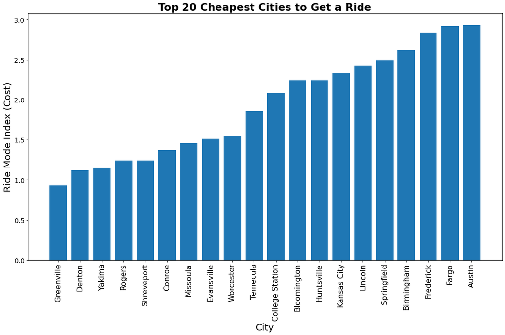

```python
# Plot a bar chart of the cheapest cities to get a ride (taxi plus transit cost)
# Start by setting up new dataframe

# Bar charts
bar_plot_y = "Ride Mode Index"
bar_plot_x = "City"

# Combine cities
taxi2drive_DF = transport_DF.groupby(bar_plot_x)[bar_plot_y].mean()
taxi2drive_DF = pd.DataFrame(taxi2drive_DF)

# Sort Values
taxi2drive_DF = taxi2drive_DF.sort_values(by=bar_plot_y, ascending=True)

# Take top cities with cheapest rides
cheapest_rides_DF = taxi2drive_DF.iloc[:20]

# Plot a bar chart of the cheapest cities to get a ride (taxi plus transit cost)
# Start by setting up new dataframe

# Bar charts
bar_plot_y = "Ride Mode Index"
bar_plot_x = "City"

# Combine cities
taxi2drive_DF = transport_DF.groupby(bar_plot_x)[bar_plot_y].mean()
taxi2drive_DF = pd.DataFrame(taxi2drive_DF)

# Sort Values
taxi2drive_DF = taxi2drive_DF.sort_values(by=bar_plot_y, ascending=True)

# Take top cities with cheapest rides
cheapest_rides_DF = taxi2drive_DF.iloc[:20]
top_20_df = cheapest_rides_DF.copy()
top_20_df.reset_index(inplace=True)

#Plot the bar chart

# Set x axis and tick locations
x_axis = np.arange(len(cheapest_rides_DF))
tick_locations = [value for value in x_axis]

# Create a list indicating where to write x labels and set figure size to adjust for space
plt.figure(figsize=(15,10))
plt.bar(x_axis, cheapest_rides_DF[bar_plot_y], align="center")
plt.xticks(tick_locations, cheapest_rides_DF.index, rotation="vertical", fontsize=16)

# Set labels for the chart
plt.title("Top 20 Cheapest Cities to Get a Ride", fontsize=22, weight = 'bold')
plt.xlabel(bar_plot_x, fontsize=20)
plt.ylabel(f'{bar_plot_y} (Cost)', fontsize=20)
plt.yticks(fontsize=14)

# Print plot
#plt.savefig("../Output Plots/Fig1b-Cheapest_Cities_for_Transportation.png",dpi=300, bbox_inches = "tight")


# Show Plot
plt.tight_layout()
plt.show()
```

```
The r-value is 0.65
The maximum price for beer is $7.88
The minimum price for beer is $3.5
The mean price of beer is $5.84
```

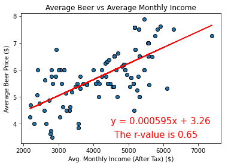

```python
ba_df = pd.read_csv(os.path.join('..', 'Outputs', 'Main_Data_Set_Cleaned.csv'))

# Dropped the null values for the average monthly income
avgincomena_DF = ba_df.dropna(subset = ['Avg. Monthly Income (After Tax)'])

# Calculate the avergae beer price between the imported and domestic beer
avgincomena_DF['Average Beer Price'] = avgincomena_DF[['Domestic Beer (Restaurant)','Imported Beer (Restaurant)']].mean(axis=1)

# Creating Scatterplot and linear regression using matplotlib

X = avgincomena_DF['Avg. Monthly Income (After Tax)']
Y = avgincomena_DF['Average Beer Price']

# Build scatter plot
plt.scatter(X, Y, marker="o", color="tab:blue", edgecolor = "black", linewidth=1)

plt.title('Average Beer vs Average Monthly Income')
plt.xlabel('Avg. Monthly Income (After Tax) ($)')
plt.ylabel('Average Beer Price ($)')

correlation = st.pearsonr(X, Y)[0]

# Draw line of best fit
slope, intercept, r_value, p_value, std_err = st.linregress(X,Y)

y_reg = slope * X + intercept
line_eq = "y = " + str(round(slope,6)) + "x + " + str(round(intercept,2))
plt.plot(X, y_reg, "r-")

# Show equation for line of best fit and r-value on graph
plt.annotate(line_eq, (4500,4),fontsize=15,color="red")
plt.annotate(f"The r-value is {round(correlation,2)}",(4600,3.5),fontsize=15,color="red")

# Calculate summary statistics for average beer price and average monthly income
mean_beer_price_allCities = Y.mean()
max_average_beerPrice = Y.max()
min_average_beerPrice = Y.min()

mean_averageIncome_allCities = X.mean()
max_averageIncome_allCities = X.max()
min_averageIncome_allCities = X.min()


# Show plot and print r-value and summary statistics
print(f"The r-value is {round(correlation,2)}")
print(f"The maximum price for beer is ${round(max_average_beerPrice,2)}")
print(f"The minimum price for beer is ${round(min_average_beerPrice,2)}")
print(f"The mean price of beer is ${round(mean_beer_price_allCities,2)}")
plt.savefig(os.path.join('..', 'Output Plots', 'avg_income_corr.png'),dpi=300, bbox_inches = "tight")
plt.show()
```

```python
df_3 = avgincomena_DF[['Country', 'State','City','Avg. Monthly Income (After Tax)']]
df_3_sorted = df_3.sort_values(by='Avg. Monthly Income (After Tax)', ascending=False)
top_10_cities_income = df_3_sorted.head(10)
top_10_cities_income.head()
```

|  | Country | State | City | Avg. Monthly Income (After Tax) |
| --- | --- | --- | --- | --- |
| 16 | United States | California | Temecula | 7388.890 |
| 101 | United States | Washington | Seattle | 6292.340 |
| 31 | United States | North Carolina | Durham | 6100.000 |
| 118 | United States | District of Columbia | Washington | 5907.320 |
| 58 | United States | California | San Diego | 5821.655 |

## Customer Profile Analysis

2. How does household type vs. location affect our target market?
   - Can these factors increase or decrease our product value?

In order to answer this question, we merged two csv files that contain population growth and US census data to analyze the US population growth and the different household types within each state to gather insight of our demographic.

By cleaning up our data to contain specific columns like each household type, city and state, and population growth, we were able to compose two bar graphs. In order to narrow down our search even further, we gathered the top 10 cities with the highest number of household types. With this cleaned up data we created the "Number of Household Types in US Cities" grouped bar chart.

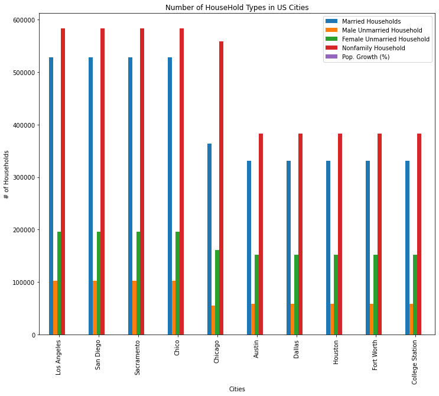

```python
# Read CSV file, label it 'df1'
df1 = pd.read_csv(os.path.join("../Outputs/US_Census_Households.csv"), delimiter =',', index_col=0,)

# Read the next CSV file, label it 'df2', and then merge df1 and df2
df2 =  pd.read_csv(os.path.join("../Outputs/Main_Data_Set_Cleaned.csv"),delimiter =',', )

# Merge Data together.
df_merge = pd.merge(df1, df2, how= 'outer', indicator=True)

# Sort the data in descending order to determine the cities with the highest total estimated households
# Drop null values
# display the top 10 cities to consider
descend_data=df_merge.sort_values('Total Estimate', ascending= False)
descend_data.dropna(axis=0, how='any', inplace=True)

#drop duplicates
drop_dup_df= descend_data.drop_duplicates(['City'])

# create a dataframe that only looks at the top 10 cities (based off of 'Total Estimate')
top10_df= drop_dup_df.iloc[:10]

#Clean the dataframe to display each city/state, household type, and population growth
clean_top10_df= top10_df[['State','City', 'Married Households','Male Unmarried Household','Female Unmarried Household', 'Nonfamily Household', 'Pop. Growth (%)',]]

#set "City" as your index
clean_top10_df.set_index('City', inplace= True)

#create a grouped bar chart to visualize and compare the different household types for the top 10 cities
households_fig1=clean_top10_df.plot(kind= 'bar', xlabel= 'Cities', ylabel= '# of Households', title= 'Number of HouseHold Types in US Cities', figsize=(12,10))
plt.savefig(os.path.join('..', 'Output Plots', 'stacked_bar_q2.png'),dpi=300, bbox_inches = "tight")
```

In this grouped bar chart, we can easily visualize how many different household types are in each of our top 10 cities. We see that California, specifically Los Angeles, San Diego, Sacramento, and Chico contain the most nonfamily households (red bar) and married households (blue bar). Following California, Texas cities like Austin, Dallas, Houston, Fort Worth, and College Station constain the most cities with potential consumers as well. Because the nature of our business venture typically attracts couples and single consumers, we can assume that these two household types in these two states are our target audience.

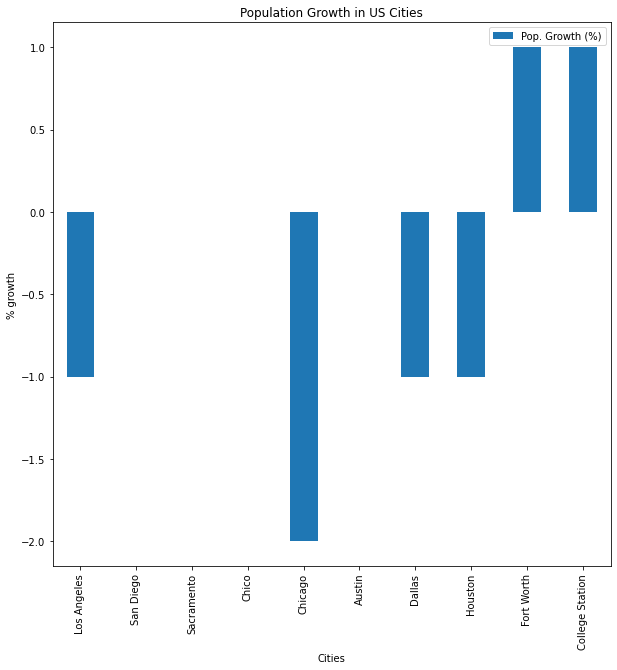

```python
# Create a dataframe that isolates the city/state and population growths and call it 'popGrowth_df'
popGrowth_df=top10_df[['State', 'City', 'Pop. Growth (%)']]

#set "City" as your index
popGrowth_df.set_index('City', inplace= True)

# Create a bar graph of the top 10 cities population growths
popGrowth_fig2=popGrowth_df.plot(kind= 'bar',xlabel='Cities', ylabel= '% growth', title= 'Population Growth in US Cities',figsize=(10,10))
plt.savefig(os.path.join('..', 'Output Plots', 'pop_growth.png'),dpi=300, bbox_inches = "tight")
```

## Customer Spending Profile

3. What are some of the spending trends the data shows around the cost of domestic beer?

On average, domestic beer is 86% of the price of imported beer. For the chart, 'Restaurant vs Home Beer, Domestic vs Import, Beer vs Food.' are we focused on cities where customers are willing to pay a premium for domestic beer, so the selected cities demonstrate this.

When examining this data, we need to look at the basics of our business: operating a brewery depends on people who enjoy drinking out, as opposed to people who enjoy drinking at home. In our dataset, the average stay-at-home consumer spends \$2.56 on a 12 oz bottle of domestic beer. Meanwhile, the average leave-the-home consumer spends about \$5.08 on a 12 oz bottle of domestic beer. This shows that ordering a beer at a restaurant is about 2 times more expensive than drinking a beer at home. Therefore, to keep price relative to average, we will cap the restaurant beer to 3 times the price of having a beer at home.

[figure not shown]

```python
# Build up the first dataframe from Nathon's lovely main dataset csv.
csv_filepath = os.path.join('..', 'Outputs', 'United_States_City_Data.csv')
beer_cost_df = pd.read_csv(csv_filepath,delimiter=",")
beer_cost_df.dropna(inplace=True)

# Isolate the columns I want to keep.
avg_beer_cost_df = beer_cost_df[['City','Domestic Beer (Restaurant)','Imported Beer (Restaurant)','Domestic Beer (Bottle)','Avg Meal Inexp. Restaurant']]
avg_beer_cost_df = avg_beer_cost_df.drop_duplicates()
# Reset Index
avg_beer_cost_df=avg_beer_cost_df.reset_index()

# I'd like to have a separate dataframe just to hold on to different types of costs.
cost_detail_df = pd.DataFrame(avg_beer_cost_df[["City"]])
cost_detail_df["Domestice Restaurant vs Home"]=""
cost_detail_df["Domestic vs Import"]=""
cost_detail_df["Domestic Beer vs Food"]=""

for i in range(len(avg_beer_cost_df)):
    city = avg_beer_cost_df.loc[i,"City"]
    domestic_beer = avg_beer_cost_df.loc[i,"Domestic Beer (Restaurant)"]
    imported_beer = avg_beer_cost_df.loc[i,"Imported Beer (Restaurant)"]
    inexp_meal = avg_beer_cost_df.loc[i,"Avg Meal Inexp. Restaurant"]
    domestic_bottle = avg_beer_cost_df.loc[i,"Domestic Beer (Bottle)"]

    domestic_rvh = domestic_beer / domestic_bottle
    domestic_import = domestic_beer / imported_beer
    domestic_food = domestic_beer / inexp_meal

    cost_detail_df.loc[i,"Domestice Restaurant vs Home"] = domestic_rvh
    cost_detail_df.loc[i,"Domestic vs Import"] = domestic_import
    cost_detail_df.loc[i,"Domestic Beer vs Food"] = domestic_food

cost_detail_df.sort_values(by=['Domestic Beer vs Food'],ascending=False,inplace=True)

# Filter to Top 10 cities
cost_top_10 = cost_detail_df[0:10]

# Let's use the top 10 to make a stacked bar chart of our expenses.
plt.bar(cost_top_10['City'], cost_top_10["Domestice Restaurant vs Home"], color='b')
plt.bar(cost_top_10['City'], cost_top_10["Domestic Beer vs Food"], color='r')
plt.bar(cost_top_10['City'], cost_top_10["Domestic vs Import"], color='orange',bottom=cost_top_10["Domestic Beer vs Food"])

plt.tick_params(axis='x', labelsize=6, rotation=45)
plt.title('Beer Spending')
plt.ylabel('USD')
plt.xlabel('City')
plt.legend(["Domestice Restaurant vs Home","Domestic vs Import","Domestic Beer vs Food"])

# Save the figure
filename=os.path.join('..', 'Output Plots', 'DomesticBeerPrices.png')
plt.savefig(filename,dpi=300, bbox_inches = "tight")

plt.show()
```

## Production Cost Estimation

4. Can Code Brews estimate our beer production costs relative to each state from the available data (i.e. water cost and electricity/utility cost)?
   - How does this impact our headquarters selection?

Estimating production costs allows for many assumptions to be made on behalf of expenses and sales. Revenue assumes the new brewery produces an equal share of the local craft beer in the city. Beer consumption per city is estimated using state beer consumption per capita and city population, and it assumes that all produced beer is sold in the taproom and none is distributed elsewhere.

Multiple sources allow us to draw expense estimates. Utilities and rent are estimated using a cost of living dataset. Labor is estimated using the latest state minimum wage and hours are fixed for all cities. The tax estimate includes a flat 21% on revenue and state beer excise taxes. With all of this, in order to calculate the profit margin, we use this formula: (revenue - expenses)/revenue. We created a subset of data to showcase the top 10 cities within analysis that contain highest profit margins. Please refer to the data below:

[output not shown]

```python
# Build up the first dataframe from Nathon's lovely main dataset csv.
csv_filepath = os.path.join('..', 'Outputs', 'Main_Data_Set_Cleaned.csv')
brewery_cost_df = pd.read_csv(csv_filepath,delimiter=",")
brewery_cost_df.dropna(inplace=True)
brewery_cost_df

# Isolate the columns I want to keep.
prod_cost_df = brewery_cost_df[['City','State','# Breweries in City','2021 Pop. Estimate','Domestic Beer (Restaurant)','Domestic Beer (Bottle)','Basic Utilities','3bd Apt. (City Center)','3bd Apt. (Outside Center)']]
prod_cost_df = prod_cost_df.drop_duplicates()

# As expected, 53 unique cities to look at.
# Pull in the consumption dataset from the Resources folder.
csv_filepath = os.path.join('..', 'Resources', 'apparent_per capita_alcohol_consumption_2018_filtered.csv')
consump_df = pd.read_csv(csv_filepath,delimiter=",")

# But wait, I have another csv to combine into this dataframe.
csv_filepath = os.path.join('..','Resources','state_minimum_wage.csv')
expenses_df = pd.read_csv(csv_filepath,delimiter=",")

# Yay, it worked.
prod_cost_df=prod_cost_df.reset_index()
'''
Revenue Methodology:
    1) Calculate total gallons of beer consumed per year:
        (State beer gallons per capita) * (2021 Pop Estimate)
    2) Multiply by 13.1% (small/independent brewers average market share in 2021 according to Brewer's Association)
        (Total gallons consumed)*0.131
    3) Divide small brewery gallons by (# Number of Breweries) + 1 (that's us)
        (Small brewery gallons)/(# Breweries +1)
    4) Calculate single brewery beers produced (and presumably sold):
        (Single brewery gallons produced) * ((128/12) standard pours/cans per gallon)
    5) Calculate revenue:
        (12oz pours produced/sold) * (price of domestic beer in a restaurant)
        Let's bump up the beer sale price a bit. You're not going to get local craft brews at big batch prices.

Expense Methodology:
    *** Ignore fixed one-time costs, like furniture, brewing equipment, etc. and assume this is already complete.
    1) Take Basic Utilities and 3bd Apt (City Center) as proxies for restaurant space rental.
        - Multiply by 3 to account for personal/business expense differences?
        - Ignore specialized water cost and roll up into utilities.
    2) Taxes. We're accounting only for state beer excise taxes and an aggressively estimated federal tax.
    3) Liquor license requirements: Annual license cost in location state divided by 12 months. Does not account for states that use lottery system or other weird nonsense.
    4) Ingredients:
        - Assume same base ingredient cost for all locations
            Why? Because most breweries get their dry ingredients shipped in anyway, they don't grow it in the backyard.
            Cost will depend on volume, which will depend on monthly production.
            Ignores potential for bulk pricing and potential shipping costs.
        - Assume we're only making a basic American pilsner, since that's what'll sell for that domestic beer price.
        - Define a formula for this, for funsies.

'''

def ingredient_cost(gals):
    ''' Using a simplified pilsner recipe from the American Homebrewer's Association and scrounged ingredient costs, calculate overall cost of ingredients for # of gallons of beer.
    The recipe uses:
        - 9 lbs of 6 row barley malt
        - 2 lbs of corn
        - 7 oz acidulated malt
        - 2.7 oz hops
        - a packet of yeast
    This yields 5.5 gallons of pilsner.

    Scrounged ingredient costs are as follows:
        - 6 row barley malt, milled: $7.99/5 lbs
        - Corn, milled: $3.99/ 5 lbs
        - Acidulated malt: $3.89/lb
        - Pellet hops: $2.49/oz
        - Lager yeast: $10.99/packet
    '''
    barley_cost = (7.99/5)*9
    corn_cost = (3.99/5)*2
    acid_malt_cost = (3.89/16)*7 #16 oz in a pound
    hops_cost = (2.49*2.7)
    yeast_cost = 10.99

    total_cost = barley_cost + corn_cost + acid_malt_cost + hops_cost + yeast_cost
    cost_per_gallon = total_cost/5.5

    return (cost_per_gallon*gals)


# Let's also make a function to calculate basic labor cost per month. For fun.
def labor_cost(min_wage):
    ''' Pass in a number for minimum wage.
    Assume all employees at minimum wage - even though often servers get paid very little and instead rely on tips. That makes the math easier.
    Assume this labor set up:
        2 servers working (8.5 hrs/day) for 5 days plus 1 server working (7.5 hrs/day) for one day
        1 manager working (4 hrs/day) for 6 days a week
        3 brewers working (8 hrs/day) for 1 day a week
    '''
    weekly_hours = (8.5*5*2)+(7.5)+(4*6)+(3*8)
    monthly_hours = weekly_hours*4

    return (monthly_hours*min_wage)

# Pull in the state excise taxes from the Resources folder.
csv_filepath = os.path.join('..', 'Resources', 'beer_excise_tax.csv')
state_tax_df = pd.read_csv(csv_filepath,delimiter=",")[['State','Excise Tax Rate ($/gal)']]

# I'd like to have a separate dataframe just to hold on to different types of costs.
cost_detail_df = pd.DataFrame(prod_cost_df[["City","State"]])
cost_detail_df["Monthly Revenue (USD)"]=""
cost_detail_df["Rent"]=""
cost_detail_df["Utilities"]=""
cost_detail_df["Ingredients"]=""
cost_detail_df["Labor"]=""
cost_detail_df["Liquor License"]=""
cost_detail_df["Tax"]=""
cost_detail_df["Monthly Expense (USD)"]=""
cost_detail_df["Profit Margin"]=""

# Let's go ahead and iterate through all rows of the dataframe, calculate revenue/expense, and populate the monthly columns.
for i in range(len(prod_cost_df)):
    state = prod_cost_df.loc[i,"State"]
    # Calculate revenue following methodology laid out above.
    gals_produced = (float(consump_df.loc[consump_df["State"]==state]["ethanol_beer_gallons_per_capita"]) * float(prod_cost_df.loc[i,"2021 Pop. Estimate"])*0.131)/(float(prod_cost_df.loc[i,"# Breweries in City"])+1)
    # That should be by year so let's divide by 12 for monthly.
    monthly_gals = gals_produced /12
    monthly_pours = monthly_gals * (128/12)
    revenue = (monthly_pours) * float(prod_cost_df.loc[i,"Domestic Beer (Restaurant)"]) *1.2

    # Populate dataframe with revenue.
    cost_detail_df.loc[i,"Monthly Revenue (USD)"]=revenue

    # Calculate state excise tax based on barrels produced.
    state_tax = monthly_gals*float(state_tax_df.loc[state_tax_df["State"]==state]["Excise Tax Rate ($/gal)"])
    # Tax is confusing and difficult, but some businesses pay a flat 21% tax and that makes the math real easy.
    fed_tax = revenue*0.21
    # Add this to the cost detail dataframe.
    cost_detail_df.loc[i,"Tax"]= state_tax+fed_tax

    # Calculate expense following methodology laid out above and add them to the cost detail dataframe.
    utilities = float(prod_cost_df.loc[i,"Basic Utilities"])*3
    cost_detail_df.loc[i,"Utilities"]= state_tax+fed_tax

    rent = float(prod_cost_df.loc[i,"3bd Apt. (City Center)"])*3 # Use city center rent, since business space is probably gonna be more in the city than outside it.
    cost_detail_df.loc[i,"Rent"]= rent

    ingredience = ingredient_cost(monthly_gals) # Yes I know it's not spelled that way
    cost_detail_df.loc[i,"Ingredients"]= ingredience

    monthly_labor = labor_cost(float(expenses_df.loc[expenses_df["State Name"]==state]["Minimum Wage"]))
    cost_detail_df.loc[i,"Labor"]= monthly_labor

    try:
        licensing = float(expenses_df.loc[expenses_df["State Name"]==state]["License Cost by Month"])
    except:
        licensing = 0
    cost_detail_df.loc[i,"Liquor License"]= licensing

    total_cost = utilities + rent + ingredience + monthly_labor + licensing + state_tax + fed_tax

    # Populate dataframe with expenses.
    cost_detail_df.loc[i,"Monthly Expense (USD)"]=total_cost

    # Calculate profit margin and populate dataframe.
    profit_margin = round((revenue - total_cost)/revenue,2)
    cost_detail_df.loc[i,"Profit Margin"]=profit_margin

cost_detail_df.sort_values(by=['Profit Margin'],ascending=False,inplace=True)

# Let's reset the index and extract columns we care about.
cost_detail_df.reset_index(inplace=True)

# Find the top 10 cities with highest profit margin for our bar chart.
top_ten_cities = cost_detail_df[0:10]
display(top_ten_cities)
```

|  | index | City | State | Monthly Revenue (USD) | Rent | Utilities | Ingredients | Labor | Liquor License | Tax | Monthly Expense (USD) | Profit Margin |
| --- | --- | --- | --- | --- | --- | --- | --- | --- | --- | --- | --- | --- |
| 0 | 49 | Los Angeles | California | 166741.281248 | 13948.65 | 35351.841 | 10816.446709 | 8711.0 | 0 | 35351.841 | 69249.047709 | 0.58 |
| 1 | 39 | Houston | Texas | 51003.58486 | 8823.57 | 10858.196116 | 4744.038305 | 4074.5 | 0 | 10858.196116 | 29007.829421 | 0.43 |
| 2 | 42 | Memphis | Tennessee | 39699.172559 | 7012.5 | 9003.648276 | 3326.391695 | 4074.5 | 0 | 9003.648276 | 23969.939971 | 0.4 |
| 3 | 4 | Fort Worth | Texas | 51710.468561 | 9075.0 | 11049.310415 | 6116.91895 | 4074.5 | 0 | 11049.310415 | 30953.229365 | 0.4 |
| 4 | 46 | Dallas | Texas | 43569.774735 | 10496.79 | 9285.80824 | 4380.851111 | 4074.5 | 0 | 9285.80824 | 28743.794351 | 0.34 |
| 5 | 32 | Jacksonville | Florida | 31832.037745 | 6348.75 | 6923.46821 | 3200.645832 | 6182.0 | 0 | 6923.46821 | 23072.014042 | 0.28 |
| 6 | 53 | Chicago | Illinois | 45880.772979 | 11825.97 | 9778.339741 | 4011.493238 | 7306.0 | 0 | 9778.339741 | 33413.14298 | 0.27 |
| 7 | 41 | Baton Rouge | Louisiana | 28640.53524 | 6500.01 | 6312.851309 | 4799.578048 | 4074.5 | 0 | 6312.851309 | 22089.599357 | 0.23 |
| 8 | 56 | Boston | Massachusetts | 48568.082553 | 14979.975 | 10258.92333 | 3488.157619 | 8430.0 | 0 | 10258.92333 | 37698.48095 | 0.22 |
| 9 | 8 | Huntsville | Alabama | 15764.820864 | 5150.01 | 3441.164804 | 1585.120268 | 4074.5 | 0 | 3441.164804 | 14758.425072 | 0.06 |

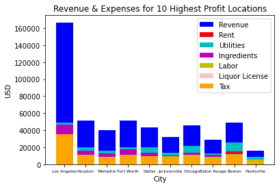

```python
# Let's use the top 10 to make a stacked bar chart of our expenses.
plt.bar(top_ten_cities['City'], top_ten_cities["Monthly Revenue (USD)"], color='b')
plt.bar(top_ten_cities['City'], top_ten_cities["Rent"], color='r')
plt.bar(top_ten_cities['City'], top_ten_cities["Utilities"], color='c',bottom=top_ten_cities["Rent"])
plt.bar(top_ten_cities['City'], top_ten_cities["Ingredients"], color='m',bottom=top_ten_cities["Utilities"])
plt.bar(top_ten_cities['City'], top_ten_cities["Labor"], color='y',bottom=top_ten_cities["Ingredients"])
plt.bar(top_ten_cities['City'], top_ten_cities["Liquor License"], color='pink',bottom=top_ten_cities["Labor"])
plt.bar(top_ten_cities['City'], top_ten_cities["Tax"], color='orange',bottom=top_ten_cities["Liquor License"])

plt.tick_params(axis='x', labelsize=6)
plt.title('Revenue & Expenses for 10 Highest Profit Locations')
plt.ylabel('USD')
plt.xlabel('City')
plt.legend(["Revenue","Rent","Utilities","Ingredients","Labor","Liquor License","Tax"])

# Save the figure
plt.savefig(os.path.join('..', 'Output Plots', 'rev_exp_bar.png'),dpi=300, bbox_inches = "tight")
plt.show()
```

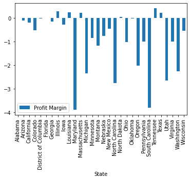

```python
# I also want to group the summary dataframe by state, take the average profit margin, and make those into a bar graph.
margin_by_state=pd.DataFrame(cost_detail_df.groupby("State")['Profit Margin'].mean())
margin_by_state.plot(kind='bar')
plt.savefig(os.path.join('..', 'Output Plots', 'profit_margin.png'),dpi=300, bbox_inches = "tight")
plt.show()
```

## Customer Base Analysis vs Current Market

To determine the viability and competitiveness of opening up a new brewery, we gathered the following data from a sample of cities in the United States:

- Number of people over the age of 19 in a city (to project earnings by opening year)
- Number of breweries in a city

The U.S. Census does not provide data for the age of 21 and above, only 20 and above. Even though 20 is not of legal drinking age in the U.S, we believe the percentage of age 20 in the dataset is not statistically significant enough to skew the results due to the sheer volume of the dataset as we are also looking to project revenues upon opening. From the data points above, the number of potential customers per brewery was calculated.

```python
# Create filepath for data import
csv_path = os.path.join('..','Outputs','Main_Data_Set_Cleaned.csv')
csv2_path = os.path.join('..','Outputs','Annual Census by City and Age.csv')

# Import the CSV into a pandas DataFrame
MainDF = pd.read_csv(csv_path)
CensusAgeDF = pd.read_csv(csv2_path)

# Merge Data
FinalDF = pd.merge(MainDF, CensusAgeDF, on=["City", "State"])

# Keep columns we are analyzing and drop any duplicates
FinalDF = FinalDF[['City','State','2021 Pop. Estimate', '% Age Over 19','# Breweries in City']]
FinalDF.drop_duplicates(inplace=True)

# Calculate People Per Brewery in the city
FinalDF['People Per Brewery'] = (FinalDF['2021 Pop. Estimate'] * FinalDF['% Age Over 19']) / FinalDF['# Breweries in City']

# Filter to potential top ten cities for analysis
FinalDF = FinalDF.sort_values(['People Per Brewery'],ascending=False)[:10]
FinalDF.head()
```

|  | City | State | 2021 Pop. Estimate | % Age Over 19 | # Breweries in City | People Per Brewery |
| --- | --- | --- | --- | --- | --- | --- |
| 41 | Baton Rouge | Louisiana | 222185 | 0.738894 | 3.0 | 54723.689441 |
| 6 | Oklahoma City | Oklahoma | 687725 | 0.730130 | 14.0 | 35866.341847 |
| 28 | Jacksonville | Florida | 954614 | 0.755015 | 21.0 | 34321.317094 |
| 32 | Tucson | Arizona | 543242 | 0.767457 | 19.0 | 21942.893959 |
| 5 | Huntsville | Alabama | 216963 | 0.758209 | 9.0 | 18278.149439 |

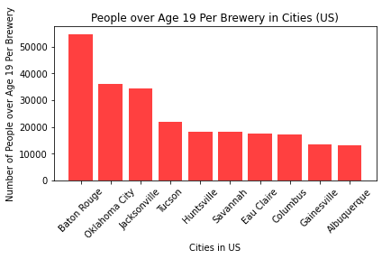

```python
# Set x axis and tick locations
x_axis = FinalDF['City']
ticks = [ x for x in x_axis]
plt.bar(x_axis , FinalDF["People Per Brewery"], color = 'red', alpha=.75, align="center")
plt.xticks(np.arange(len(FinalDF)), rotation=45)
plt.xlabel("Cities in US")
plt.ylabel("Number of People over Age 19 Per Brewery")
plt.title("People over Age 19 Per Brewery in Cities (US)")
plt.tight_layout()
plt.savefig(os.path.join('..', 'Output Plots', 'people_over_19.png'),dpi=300, bbox_inches = "tight")
plt.show()
```

## Conclusion

In order to come up with a location we can combine these different analyses which have indicated a ranking structure to compare our key indicators for selecting a city to launch our brewery. We are chosing to do this by finding the most common high ranking city across all of Code Brews' analyses.

```python
# Here is how we will name our top contender for a prospective location.
# Take the top 10-20 cities from each analysis and see which city consistently shows up in the majority of the data collected
df_list = [top_20_df, top_10_cities_income, top10_df, cost_top_10, top_ten_cities, FinalDF]

# Create Empty Series to store cities from our key performance indecators from our analysis.
cities_kpi = pd.Series()

# Loop through our end each question's DataFrames
for df in range(len(df_list)):
    temp = df_list[df]
    cities_kpi =pd.concat([cities_kpi,temp['City']], axis=0, ignore_index=True)

# Pass to DF
cities_kpi_df = pd.DataFrame(cities_kpi.value_counts()).reset_index().rename(columns={'index':'Top City', 0:'Count'})

city = cities_kpi_df['Top City'][0]
display(cities_kpi_df.head(1))
```

|  | Top City | Count |
| --- | --- | --- |
| 0 | Austin | 4 |

Here is our median profile for the selected city.

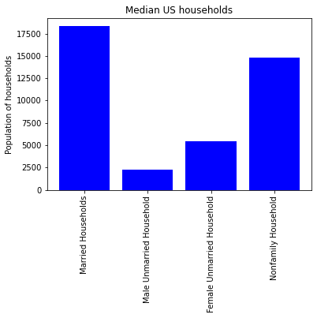

```python
# Create Plot of US Median
median_US_households = ["Married Households", "Male Unmarried Household", "Female Unmarried Household", "Nonfamily Household"]
number_of_households = [median_married_US, median_male_US, median_Female_US, median_single_US]
x_axis = np.arange(len(number_of_households))
plt.bar(x_axis, number_of_households, color="b", align="center")
tick_locations = [value for value in x_axis]
plt.xticks(tick_locations, median_US_households)
plt.xticks(x_axis, rotation=90)
plt.title("Median US households")
plt.ylabel("Population of households")
plt.savefig(os.path.join('..', 'Output Plots', 'median_us.png'),dpi=300, bbox_inches = "tight")
plt.show()
```

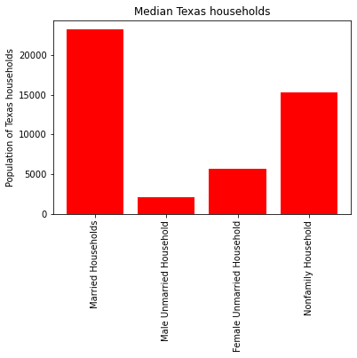

```python
# Create Plot of State Medians
state_medain_households = ["Married Households", "Male Unmarried Household", "Female Unmarried Household", "Nonfamily Household"]
number_of_state_households = [state_median, state_median_male, state_median_female, state_median_single]
x_axis = np.arange(len(number_of_state_households))
plt.bar(x_axis, number_of_state_households, color="r", align="center")
tick_locations = [value for value in x_axis]
plt.xticks(tick_locations, state_medain_households)
plt.xticks(x_axis, rotation=90)
plt.title(f"Median {state} households")
plt.ylabel(f"Population of {state} households")
plt.savefig(os.path.join('..', 'Output Plots', 'median_state.png'),dpi=300, bbox_inches = "tight")
plt.show()
```

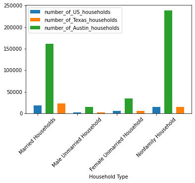

```python
# Create Stacked Bar Plot of all medians and city data.
median_US_households = ["Married Households", "Male Unmarried Household", "Female Unmarried Household", "Nonfamily Household"]
number_of_households = [median_married_US, median_male_US, median_Female_US, median_single_US]
state_medain_households = ["Married Households", "Male Unmarried Household", "Female Unmarried Household", "Nonfamily Household"]
number_of_state_households = [state_median, state_median_male, state_median_female, state_median_single]
city_medain_households = ["Married Households", "Male Unmarried Household", "Female Unmarried Household", "Nonfamily Household"]
number_of_city_households = [city_df['Married Households'].item(), city_df['Male Unmarried Household'].item(),
                                 city_df['Female Unmarried Household'].item(), city_df['Nonfamily Household'].item()]
x_axis = np.arange(len(number_of_households))

#Create the first bar chart
plt.bar(x_axis+0.0, number_of_households, width=0.2)

#Create the second bar chart
plt.bar(x_axis+0.6, number_of_state_households, width=0.2)

#Create the third bar chart
plt.bar(x_axis+0.3, number_of_city_households, width=0.2)

#Label the x-axis
plt.xlabel('Household Type')

plt.xticks(tick_locations, state_medain_households)
plt.xticks(x_axis, rotation=45)

plt.legend(['number_of_US_households', f'number_of_{state}_households', f'number_of_{city}_households'])
plt.savefig(os.path.join('..', 'Output Plots', 'median_stacked_bar.png'),dpi=300, bbox_inches = "tight")
#Show the plot
plt.show()
```

```python
# Plot Competitors in selected city.
OBD_response = requests.get("https://api.openbrewerydb.org/breweries",params={'by_city': city}).json()
OBD_df = pd.json_normalize(OBD_response)
OBD_df.dropna(subset='longitude',inplace=True)
OBD_df = OBD_df[OBD_df['state'] == state]
OBD_df[['longitude','latitude']] = OBD_df[['longitude','latitude']].astype(float)
OBD_df = OBD_df[OBD_df['longitude'] > -98]
OBD_df.reset_index(drop=True,inplace=True)
OBD_df.hvplot.points('longitude', 'latitude', geo=True, tiles='CartoLight', color='name', size=40,frame_height=500, frame_width=500,
                    hover_cols=['brewery_type', 'street','postal_code', 'city', 'state' ,'phone', 'website_url'])
```

[interactive chart not shown]

### Data Sets Used:

- US Census Buerau - API Collection
- Cost of Living Data - Kaggle - https://www.kaggle.com/datasets/mvieira101/global-cost-of-living?select=cost-of-living.csv
- Craft Beer Data - Kaggle - https://www.kaggle.com/nickhould/craft-cans
- Open Brewery DB - API
- 2018 Per Capita Beer Consumption: https://www.kaggle.com/datasets/osamaabdullatif/apparent-per-capita-alcohol-consumption-19772018
- 21% Tax Rate (for some corporations): https://www.irs.gov/publications/p542#en_US_202201_publink1000257885
- State Minimum Wage: https://www.dol.gov/agencies/whd/minimum-wage/state
- State Liquor Licenses: https://ballotpedia.org/Liquor_license_costs_by_state,_2018
- 2021 Market Share: https://www.brewersassociation.org/statistics-and-data/national-beer-stats/
- American Pilsner Homebrew Recipe: https://www.homebrewersassociation.org/homebrew-recipe/big-brew-2013-recipe-classic-american-pilsner/
- Corn & Barley Pricing: https://moonshinedistiller.com/ingredients/distilling-grains/
- Yeast and hops Pricing: https://www.morebeer.com/category/brewing-ingredients.html
- State Beer Excise Taxes: https://taxfoundation.org/state-beer-taxes-2021/